## Relationships of social climate and indoor environmental quality and frequently reported health symptoms in a suburban school district

**Sheena E. Martenies**<sup>1</sup>, Jen Schill<sup>2</sup>, Matthew Klimm<sup>2</sup>, Jeni Cross<sup>2,3</sup>, Shannon Oliver<sup>4</sup>, Sheryl Magzamen<sup>1,5</sup>

<sup>1</sup> Department of Environmental and Radiological Health Sciences, Colorado State University

<sup>2</sup> Institute for the Built Environment, Colorado State University

<sup>3</sup> Department of Sociology, Colorado State University

<sup>4</sup> Manager, Energy and Sustainability, Partnering School District

<sup>5</sup> Department of Epidemiology, Colorado School of Public Health

**Contact Us:**

Sheena.Martenies@colostate.edu

GitHub: smartenies/MAPERC_Teacher_Study

### 1. Project overview

This document summarizes the analyses of school-level social climate score and individual-level self-reported health outcomes for teachers and staff in our participating school district.

#### 1.1 Objectives

The primary objective of this study was to assess whether social climate scores at the school level were associated with self-reported number of frequent (i.e., experienced at least once per week) health symptoms among faculty and staff working in our partner school district. We also examined if indoor air quality scores were associated with health symptoms and whether social climate scores were a modifier of this effect.

### 2. Methods

#### 2.1 ELEVATE Survey

Staff at elementary, middle, and high schools in our participating district completed a social climate survey assessing their attitudes about their schools. Among other questions, these surveys assessed whether staff would recommend their schools to colleagues or friends looking for a job, how positive staff perceived the interactions between teachers and students to be, and whether staff were optimistic about their schools improving in the future. Data from these surveys was available at the school level. Our primary outcome from this survey was the overall social climate score, which accounts for responses to several of the survey’s questions. We also used individual questions on the survey in secondary analyses. Higher climate scores correspond with more positive social climates as perceived by staff.

#### 2.2 Indoor Environment Survey

We also collected data on self-reported health symptoms at the individual level. These data came from an indoor environment survey that included questions on how indoor environmental variables such as lighting, noise, and air quality impacted the ability of staff to complete their jobs. This questionnaire asked teachers whether they experienced any of the following symptoms and, if yes, how frequently they experienced them:

- Headaches
- Wheezing (breathing with a whistling or rattling sound in your chest)
- Dry, itchy, or irritated eyes
- Sore or dry throat
- Stuffy or runny nose, or sinus congestion
- Sneezing
- Tired or strained eyes
- Tension, irritability, or nervousness
- Having a hard time paying attention
- Dizziness or lightheadedness
- Nausea or upset stomach
- Feeling depressed
- Feeling tired or lethargic

Our primary outcome of interest was the number of frequent heath symptoms reported by each individual. We considered a health outcome to be “frequent” if it occurred at least once a week. In secondary analyses, We also explored associations between social climate scores at the school level and frequent occurrence of each health outcome as a binary variable.

#### 2.3 Operational Report Card (ORC) Data

Operational report card (ORC) scores were used to characterize the quality of the built environment in each school. Overall ORC scores were based on the average score in five operations areas: energy efficiency, thermal comfort, acoustics, visual quality, and indoor air quality (IAQ). ORC scores were generated from a building survey completed by a graduate student completing walk-throughs of each participating school. Higher ORC scores were associated with higher quality indoor environments in the schools. We were also interested in the IAQ component of the ORC score as a separate predictor in our model due to known associations between indoor contaminants and the health outcomes included in our survey. Both the mean overall ORC score and the IAQ score for each school were included in models as continuous variables.

#### 2.4 Statistical Analysis

Social climate survey data, ORC scores (overall and IAQ), and the number of frequent health outcomes were summarized as means and standard deviations (SD) or counts and frequencies as appropriate. We explore correlations between variables using Pearson’s r statistic.

Associations between social climate scores and the number of frequent health outcomes were assessed using generalized linear models with a Poisson log-link function with random effects for schools. To improve model convergence, the social climate scores and ORC scores were scaled prior to model fitting. We therefore report effect sizes for a standard deviation increase in social climate score or ORC score.

We also assessed relationships between social climate scores and individual health outcomes operationalized as binomial outcomes. We again used a generalized linear model with random effects for school and scaled exposure variables.

For each of our models, we assessed interactions between social climate scores and job category (teacher vs. other)

All analyses were completed in R version 3.6.0 (2019-04-26).

### 3. Results

#### 3.1 Study Population

Overall, we collected data from 134 participants representing 11 schools. The median (range) number of surveys collected from each school was 10 (5 - 24).

Our survey was available to teachers and other staff at the school. Overall, 10 different job categories were represented (Table 1). Teachers made up the greatest percentage of participants (61.9%)

Table 1. Summary of job categories represented

| Job Category | Count | Percent |
| --- | --- | --- |
| Teacher | 83 | 61.9 |
| Other, Not Specified | 10 | 7.5 |
| Administrator | 9 | 6.7 |
| Counselor | 8 | 6.0 |
| Operations | 6 | 4.5 |
| Paraeducator | 6 | 4.5 |
| Aide or Monitor | 5 | 3.7 |
| Health Aide | 3 | 2.2 |
| Coach | 2 | 1.5 |
| Media Technician | 2 | 1.5 |

#### 3.2 Social Climate and Indoor Air Quality

There was substantial variability in the distribution of social climate scores across schools (Table 2). The scores ranged from 51 to 92, with a median of 60.5.

Table 2. Summary of climate survey scores and operational report card (ORC) scores

| Variable | Mean (SD) | Min | Median | Max |
| --- | --- | --- | --- | --- |
| Social climate score | 63.7 (10.5) | 51.0 | 60.5 | 92.0 |
| Mean ORC score | 67.4 (4.4) | 54.4 | 67.8 | 73.8 |
| Indoor air quality (IAQ) score | 72.5 (10.5) | 45.0 | 74.0 | 83.0 |

#### 3.3 Frequently Reported Health Symptoms

The number of frequent health outcomes reported ranged from 0 to 10 (Table 3). Teachers reported a slightly greater number of symptoms on average compared to other staff members (3.2 vs. 2.3, p = 0.07). The most common frequent health symptoms among all staff were eye strain (44%) and lethargy or tiredness (37%).

|  | All (N = 134) | Not Teachers (N = 51) | Teachers (N = 83) |
| --- | --- | --- | --- |
| **Number of frequent symptoms reported** |  |  |  |
| Min | 0 | 0 | 0 |
| Max | 10 | 10 | 10 |
| Mean (SD) | 2.86 ± 2.87 | 2.27 ± 2.96 | 3.22 ± 2.77 |
| **Headaches** |  |  |  |
| N (%) | 38 (31) | 14 (31) | 24 (31) |
| **Wheeze** |  |  |  |
| N (%) | 6 (5) | 1 (2) | 5 (7) |
| **Eye irritation** |  |  |  |
| N (%) | 38 (31) | 11 (25) | 27 (35) |
| **Sore throat** |  |  |  |
| N (%) | 29 (24) | 7 (16) | 22 (28) |
| **Sinus symptoms** |  |  |  |
| N (%) | 38 (31) | 10 (23) | 28 (36) |
| **Sneeze** |  |  |  |
| N (%) | 37 (30) | 14 (31) | 23 (29) |
| **Eye strain** |  |  |  |
| N (%) | 53 (44) | 14 (32) | 39 (51) |
| **Tension, irritability, or nervousness** |  |  |  |
| N (%) | 38 (31) | 12 (28) | 26 (33) |
| **Lack of attention** |  |  |  |
| N (%) | 20 (16) | 7 (16) | 13 (17) |
| **Dizziness or lightheadedness** |  |  |  |
| N (%) | 14 (11) | 8 (18) | 6 (8) |
| **Nausea** |  |  |  |
| N (%) | 8 (7) | 1 (2) | 7 (9) |
| **Feeling depressed** |  |  |  |
| N (%) | 18 (15) | 4 (9) | 14 (18) |
| **Lethargy or tiredness** |  |  |  |
| N (%) | 46 (37) | 13 (29) | 33 (42) |

#### 3.4 Correlations between outcomes and exposures

Overall social climate scores were negatively correlated with the number of frequent symptoms reported (r = -0.16) and the percentage of students at the school who qualified for free or reduced lunch (r = -0.56) (Figure 1). The social climate score was also negatively correlated with the mean ORC score (r = -0.34) and the indoor air quality score (r = -0.58).

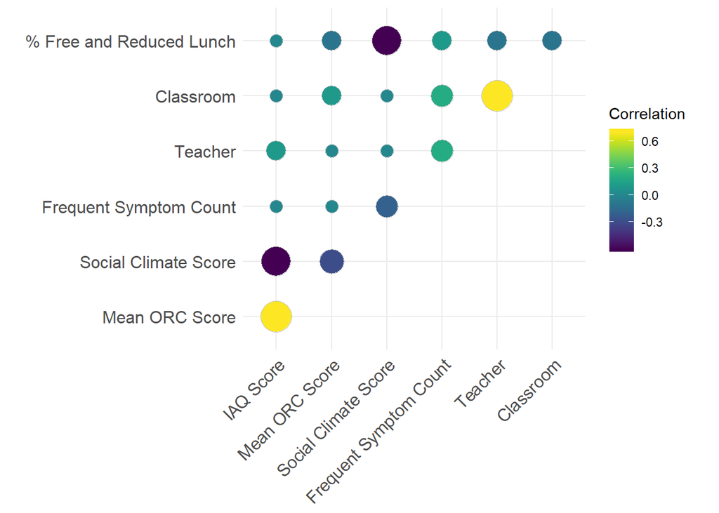

Figure 1. Correlations between variables

#### 3.5 Associations between social climate scores and the number of frequent health outcomes reported

In models adjusted for being a teacher (binary), working in a classroom (binary), the percentage of students who qualify for free or reduced lunch (continuous), and the indoor air quality score (continuous), overall campus climate scores were negatively associated with the number of frequent health effects reported by staff at the schools (Table 4). A standard deviation increase in the campus social climate score was associated with 0.68-fold (95% confidence interval (CI): 0.48 - 0.95) change in the rate of frequent health outcomes reported by staff.

Table 4. Associations between IAQ and social climate scores and the number of frequent health effects reported

|  | Frequent Health Outcomes |  |
| --- | --- | --- |
| Predictors | Incidence Rate Ratios | CI |
| Intercept | 2.69 | 1.42 – 5.10 |
| Social Climate Score | 0.68 | 0.48 – 0.95 |
| IAQ Score | 0.86 | 0.66 – 1.12 |
| Teacher | 1.20 | 0.89 – 1.61 |
| Classroom | 1.20 | 0.87 – 1.66 |
| % Free and Reduced Lunch | 0.59 | 0.19 – 1.81 |
| Random Effects |  |  |
| σ<sup>2</sup> | 0.33 |  |
| τ<sub>00</sub> <sub>school</sub> | 0.06 |  |
| ICC | 0.16 |  |
| N <sub>school</sub> | 11 |  |
| Observations | 134 |  |
| Marginal R<sup>2</sup> / Conditional R<sup>2</sup> | 0.195 / 0.324 |  |

Table 5. Assessing effect modification of social climate scores on associations between IAQ and the number of frequent health outcomes reported

|  | All Staff |  | Staff at High Social Climate Schools |  | Staff at Low Social Climate Schools |  |
| --- | --- | --- | --- | --- | --- | --- |
| Predictors | Incidence Rate Ratios | CI | Incidence Rate Ratios | CI | Incidence Rate Ratios | CI |
| Intercept | 1.71 | 0.96 – 3.02 | 0.55 | 0.18 – 1.66 | 4.32 | 2.75 – 6.79 |
| IAQ Score | 1.08 | 0.88 – 1.34 | 0.96 | 0.72 – 1.28 | 0.49 | 0.35 – 0.70 |
| Teacher | 1.20 | 0.89 – 1.62 | 3.40 | 1.38 – 8.41 | 0.96 | 0.70 – 1.32 |
| Classroom | 1.20 | 0.86 – 1.65 | 1.62 | 0.54 – 4.86 | 1.13 | 0.80 – 1.58 |
| % Free and Reduced Lunch | 1.44 | 0.57 – 3.63 | 0.84 | 0.16 – 4.44 | 0.77 | 0.44 – 1.34 |
| Random Effects |  |  |  |  |  |  |
| σ<sup>2</sup> | 0.33 |  | 0.45 |  | 0.28 |  |
| τ<sub>00</sub> | 0.10 <sub>school</sub> |  | 0.08 <sub>school</sub> |  | 0.00 <sub>school</sub> |  |
| ICC | 0.23 |  | 0.15 |  |  |  |
| N | 11 <sub>school</sub> |  | 4 <sub>school</sub> |  | 7 <sub>school</sub> |  |
| Observations | 134 |  | 40 |  | 94 |  |
| Marginal R<sup>2</sup> / Conditional R<sup>2</sup> | 0.079 / 0.294 |  | 0.539 / 0.608 |  | 0.219 / NA |  |

We also observed differences in how social environment scores were associated with the number of frequent health effects reported by job status. For teachers, the association between social climate scores and frequent health effects was attenuated compared to other staff members (Figure 2).

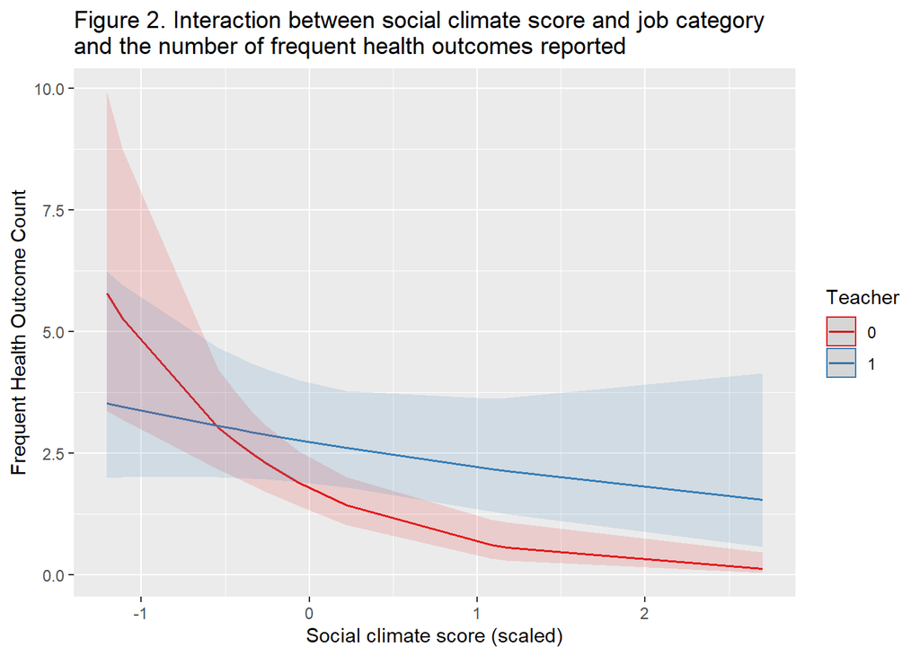

#### 3.6 Associations between social climate scores and specific frequent health outcomes

Table 6. Associations between social climate score and frequent health outcomes

|  | Frequent Headaches |  | Frequent Dizziness |  | Frequent Lethargy |  | Frequent Depression |  |
| --- | --- | --- | --- | --- | --- | --- | --- | --- |
| Predictors | Odds Ratios | CI | Odds Ratios | CI | Odds Ratios | CI | Odds Ratios | CI |
| Intercept | 0.63 | 0.14 – 2.78 | 0.40 | 0.05 – 3.42 | 1.74 | 0.41 – 7.33 | 0.13 | 0.02 – 0.99 |
| Social Climate Score | 0.49 | 0.24 – 1.02 | 0.29 | 0.07 – 1.11 | 0.35 | 0.17 – 0.72 | 0.50 | 0.18 – 1.40 |
| IAQ Score | 0.52 | 0.29 – 0.95 | 0.54 | 0.20 – 1.45 | 0.63 | 0.35 – 1.15 | 1.13 | 0.40 – 3.23 |
| Teacher | 0.58 | 0.18 – 1.83 | 0.15 | 0.03 – 0.69 | 2.34 | 0.71 – 7.72 | 9.94 | 1.41 – 70.37 |
| Classroom | 2.43 | 0.71 – 8.25 | 3.79 | 0.76 – 18.82 | 0.60 | 0.17 – 2.08 | 0.14 | 0.02 – 0.89 |
| % Free and Reduced Lunch | 0.24 | 0.02 – 3.00 | 0.08 | 0.00 – 4.10 | 0.06 | 0.01 – 0.75 | 0.68 | 0.03 – 17.02 |
| Random Effects |  |  |  |  |  |  |  |  |
| σ<sup>2</sup> | 3.29 |  | 3.29 |  | 3.29 |  | 3.29 |  |
| τ<sub>00</sub> | 0.00 <sub>school</sub> |  | 0.00 <sub>school</sub> |  | 0.00 <sub>school</sub> |  | 0.00 <sub>school</sub> |  |
| N | 11 <sub>school</sub> |  | 11 <sub>school</sub> |  | 11 <sub>school</sub> |  | 11 <sub>school</sub> |  |
| Observations | 123 |  | 123 |  | 123 |  | 123 |  |
| Marginal R<sup>2</sup> / Conditional R<sup>2</sup> | 0.091 / NA |  | 0.226 / NA |  | 0.134 / NA |  | 0.290 / NA |  |

We observed an interaction between being a teacher and overall social climate scores on the odds of frequent depression symptoms (Figure 3). For teachers, the effect of social climate on the odds of frequent depression was attenuated relative to those not working as teachers.

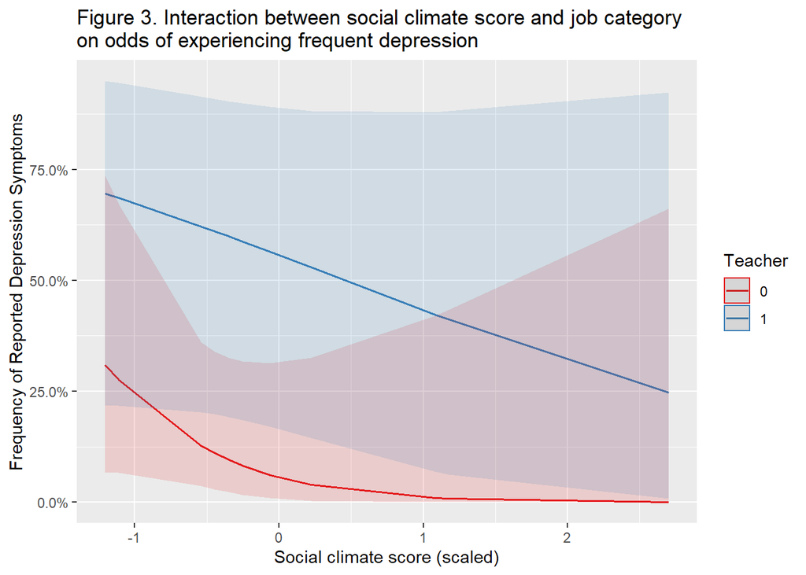

### 4. Summary of main findings

Social climate scores may modify the effect of indoor air quality on the rate of frequently reported health symptoms. Staff in schools with higher social climate scores had lower rates of frequent health outcomes compared to staff from low social climate schools.

We also found that that the relationship between higher social climate scores and lower rates of frequent health symptoms was attenuated for participants who were teachers compared to other job categories. As social climate scores were only available at the school level, we were not able to assess whether there were differences in how teachers assess their schools’ social climates relative to other staff working in the school.